# How does my heart rate vary throughout the day?

STATS 220 Semester One 2025

William Tess (907749468, wte651)

## How does my heart rate vary throughout the day?

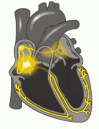

This visual story aims to communicate how my personal heart rate varies throughout a day based on factors such as what activity I’m doing, what time of the day I’m doing them, and how long it took to complete those activities. The data used for this story was collected using a Google form that I filled in myself throughout a period of about two weeks.

## Which times of the day is heart rate highest?

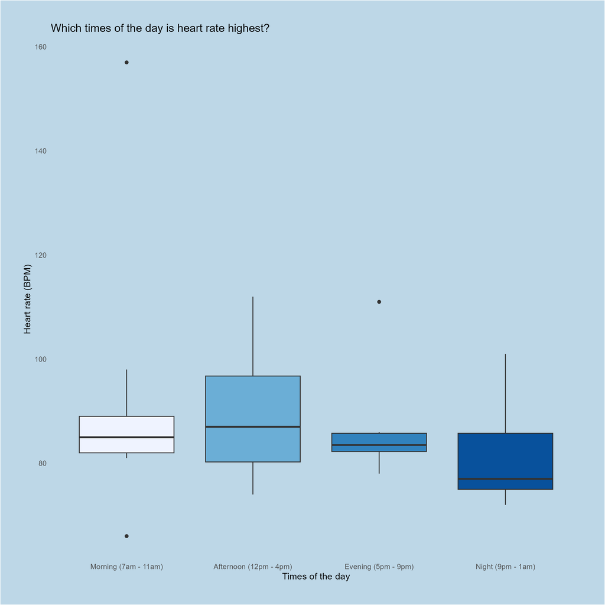

boxplot

This boxplot demonstrates how heart rate changes based on different times of the day. We can see that my heart rate tends to be lowest at night, which makes sense as I am usually winding down to get ready for bed around this time. It is usually highest in the afternoon with the most amount of variation. This also makes sense as my heart rate can change quite drastically based on what I’m doing during the day. Heart rate is quite similar between the morning and the evening, as these are usually the time periods where I am getting ready for my day, or getting ready to wind down.

## Which types of activites have the highest heart rate?

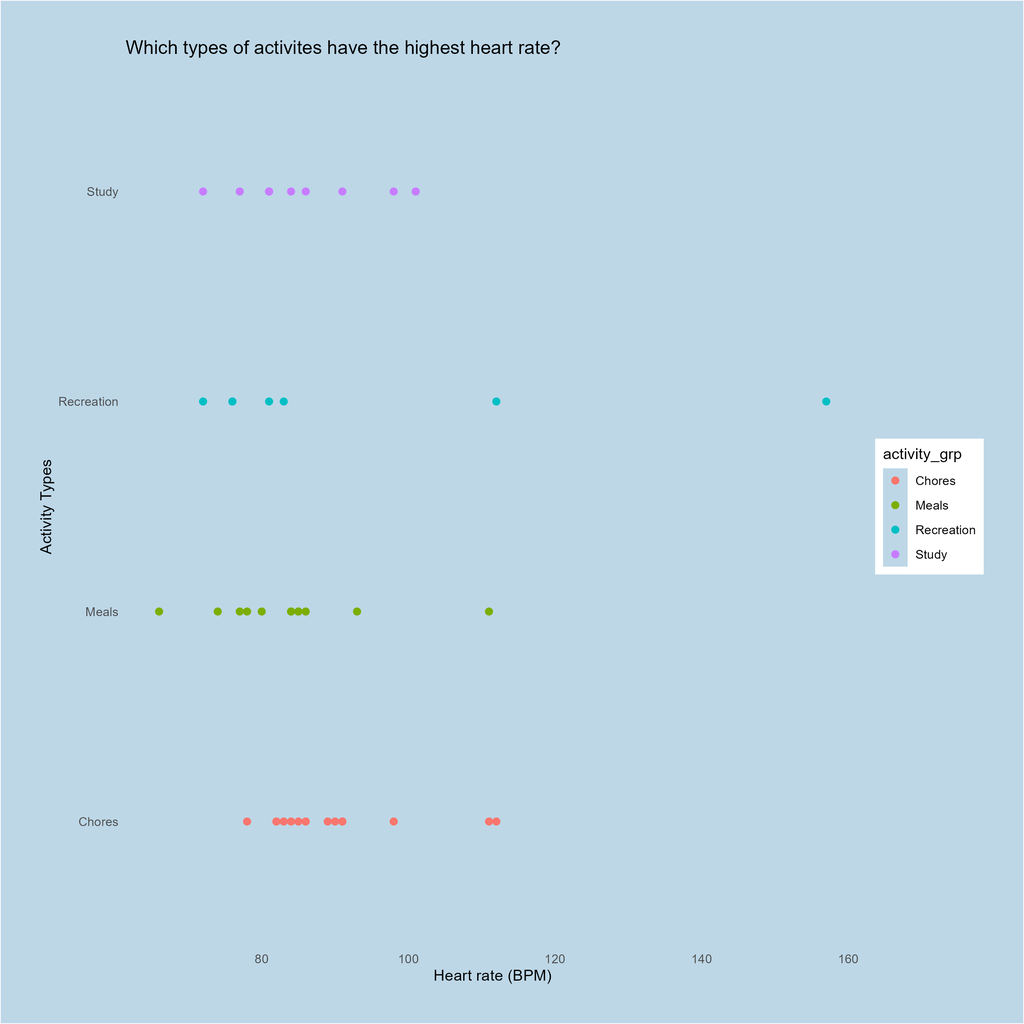

scatterplot

We can see based on this scatterplot that my heart rate is quite consistent when I’m doing chores. This would make sense as I personally do specific types of chores around my house, which would result in very similar heart rates (such as doing the dishes or the laundry). Heart rate is most varied during recreation, which includes my highest recorded heart rate. This observation is also unsurprising as recreation includes the various forms of exercise I do while taking breaks, such as going on a walk or a jog. I have the lowest heart rate during meals, as my body is in “rest and digest”. It is also fairly low while I’m studying and not physically exerting myself.

## Which activities take the longest?

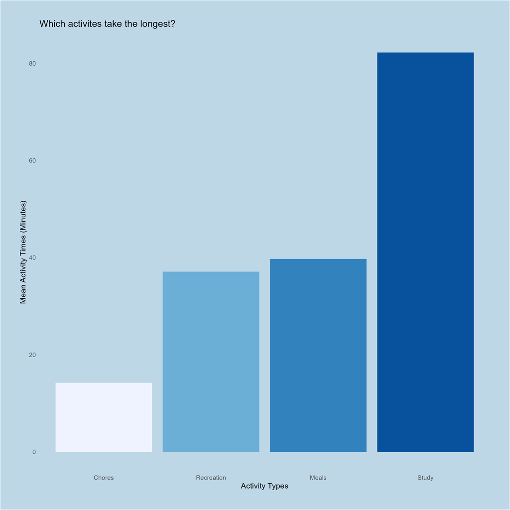

barchart

The longest type of activity for me was studying, which makes sense as a single study session can easily last a couple hours. In contrast, chores had the shortest average time as they are jobs I can usually finish fairly quickly. I spent about the same amount of time on meals as I did recreation. This makes sense as the time it takes for me to sit down and finish a meal is usually just under an hour, and my recreational breaks is usually between 30-60min as well.